# Analisi dades

Laura Guzman

16 d’agost de 2019

```r
library(ggplot2)
library(timeDate)
library(lubridate)
library(gdata)
library(knitr)
```

**Negreta** *Cursiva*

# Weather hourly

```r
#Carreguem arxiu de dades
weather_hourly <-read.csv(file="dades/6weather_hourly_darksky.csv", header=TRUE, sep=",")
```

```r
#Resum dades

#Dimensi?
dim(weather_hourly)
```

```
## [1] 21165    12
```

```r
# Resum
summary(weather_hourly)
```

```
##    visibility     windBearing     temperature
##  Min.   : 0.18   Min.   :  0.0   Min.   :-5.64
##  1st Qu.:10.12   1st Qu.:121.0   1st Qu.: 6.47
##  Median :12.26   Median :217.0   Median : 9.93
##  Mean   :11.17   Mean   :195.7   Mean   :10.47
##  3rd Qu.:13.08   3rd Qu.:256.0   3rd Qu.:14.31
##  Max.   :16.09   Max.   :359.0   Max.   :32.40
##
##                   time          dewPoint         pressure
##  2011-11-01 00:00:00:    1   Min.   :-9.980   Min.   : 975.7
##  2011-11-01 01:00:00:    1   1st Qu.: 2.820   1st Qu.:1007.4
##  2011-11-01 02:00:00:    1   Median : 6.570   Median :1014.8
##  2011-11-01 03:00:00:    1   Mean   : 6.531   Mean   :1014.1
##  2011-11-01 04:00:00:    1   3rd Qu.:10.330   3rd Qu.:1022.0
##  2011-11-01 05:00:00:    1   Max.   :19.880   Max.   :1043.3
##  (Other)            :21159                    NA's   :13
##  apparentTemperature   windSpeed      precipType
##  Min.   :-8.88       Min.   : 0.040   rain:20370
##  1st Qu.: 3.90       1st Qu.: 2.420   snow:  795
##  Median : 9.36       Median : 3.680
##  Mean   : 9.23       Mean   : 3.905
##  3rd Qu.:14.32       3rd Qu.: 5.070
##  Max.   :32.42       Max.   :14.800
##
##                   icon         humidity
##  clear-day          :1110   Min.   :0.2300
##  clear-night        :4661   1st Qu.:0.7000
##  cloudy             : 979   Median :0.8100
##  fog                : 693   Mean   :0.7818
##  partly-cloudy-day  :7658   3rd Qu.:0.8900
##  partly-cloudy-night:5075   Max.   :1.0000
##  wind               : 989
##                      summary
##  Partly Cloudy           :6638
##  Mostly Cloudy           :6095
##  Clear                   :5771
##  Overcast                : 979
##  Foggy                   : 693
##  Breezy and Mostly Cloudy: 385
##  (Other)                 : 604
```

```r
# Tipus de dades
str(weather_hourly)
```

```
## 'data.frame':    21165 obs. of  12 variables:
##  $ visibility         : num  5.97 4.88 3.7 3.12 1.85 1.96 1.3 1.22 1.4 1.38 ...
##  $ windBearing        : int  104 99 98 99 111 115 118 114 120 121 ...
##  $ temperature        : num  10.24 9.76 9.46 9.23 9.26 ...
##  $ time               : Factor w/ 21165 levels "2011-11-01 00:00:00",..: 241 242 243 244 245 246 247 248 249 250 ...
##  $ dewPoint           : num  8.86 8.83 8.79 8.63 9.21 8.87 8.82 8.69 8.75 8.7 ...
##  $ pressure           : num  1017 1017 1016 1016 1016 ...
##  $ apparentTemperature: num  10.24 8.24 7.76 7.44 7.24 ...
##  $ windSpeed          : num  2.77 2.95 3.17 3.25 3.7 3.97 4.1 4.23 4.2 3.96 ...
##  $ precipType         : Factor w/ 2 levels "rain","snow": 1 1 1 1 1 1 1 1 1 1 ...
##  $ icon               : Factor w/ 7 levels "clear-day","clear-night",..: 6 6 6 4 4 4 4 4 4 4 ...
##  $ humidity           : num  0.91 0.94 0.96 0.96 1 0.97 0.97 0.99 0.97 0.97 ...
##  $ summary            : Factor w/ 13 levels "Breezy","Breezy and Mostly Cloudy",..: 9 9 9 6 6 6 6 6 6 6 ...
```

```r
#Convertim time en timedate enlloc de factor
weather_hourly$time<-as.timeDate(weather_hourly$time)
```

```r
#Comprovem que no hi hagi noms repetits escrits diferent
summary(weather_hourly$icon)
```

```
##           clear-day         clear-night              cloudy
##                1110                4661                 979
##                 fog   partly-cloudy-day partly-cloudy-night
##                 693                7658                5075
##                wind
##                 989
```

```r
summary(weather_hourly$summary)
```

```
##                   Breezy Breezy and Mostly Cloudy      Breezy and Overcast
##                      195                      385                       83
## Breezy and Partly Cloudy                    Clear                    Foggy
##                      267                     5771                      693
##            Mostly Cloudy                 Overcast            Partly Cloudy
##                     6095                      979                     6638
##                    Windy  Windy and Mostly Cloudy       Windy and Overcast
##                       18                       29                        9
##  Windy and Partly Cloudy
##                        3
```

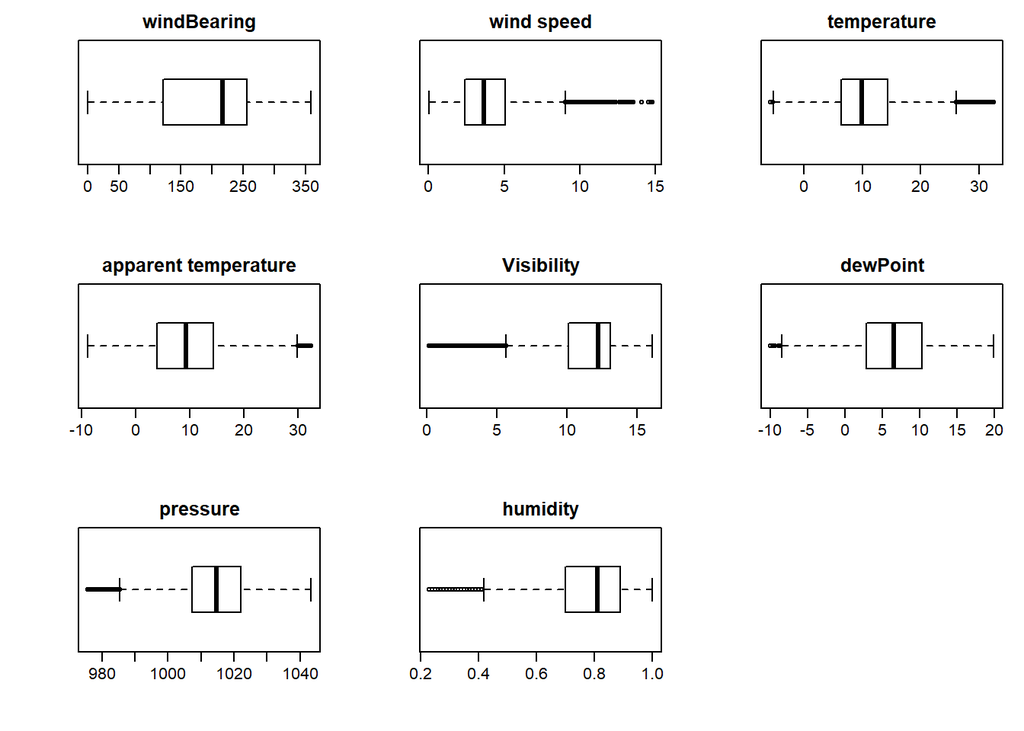

```r
#Boxplot

library(sfsmisc)
mult.fig(8)

boxplot(weather_hourly$windBearing, main="windBearing",horizontal = TRUE)
boxplot(weather_hourly$windSpeed, main="wind speed",horizontal = TRUE)

boxplot(weather_hourly$temperature, main="temperature",horizontal = TRUE)
boxplot(weather_hourly$apparentTemperature, main="apparent temperature",horizontal = TRUE)
boxplot(weather_hourly$visibility, main="Visibility",horizontal = TRUE)
boxplot(weather_hourly$dewPoint, main="dewPoint",horizontal = TRUE)
boxplot(weather_hourly$pressure, main="pressure",horizontal = TRUE)
boxplot(weather_hourly$humidity, main="humidity",horizontal = TRUE)
```

```r
#Mirem si cont? valors buits
colSums(is.na(weather_hourly))
```

```
##          visibility         windBearing         temperature
##                   0                   0                   0
##                time            dewPoint            pressure
##                   0                   0                  13
## apparentTemperature           windSpeed          precipType
##                   0                   0                   0
##                icon            humidity             summary
##                   0                   0                   0
```

Comprovem quines files tenen els valors buits de pressure.

```r
weather_hourly[is.na(weather_hourly$pressure),]
```

```
##       visibility windBearing temperature                time dewPoint
## 5348       11.27         189       12.99 2012-05-07 18:00:00     8.29
## 8418       11.27          21        7.29 2012-10-26 15:00:00     3.68
## 12085       7.24         252       18.09 2013-09-13 11:00:00    16.38
## 13281       9.66         250        9.65 2013-01-03 07:00:00     8.67
## 13538       6.39          10       17.56 2013-08-25 23:00:00    15.49
## 13539       4.39         358       17.02 2013-08-26 00:00:00    15.42
## 15340       9.98         217       17.01 2013-08-16 01:00:00    14.84
## 17904       9.98         193       19.16 2013-08-01 00:00:00    16.78
## 18661       9.98          48       13.42 2013-06-09 13:00:00     7.76
## 18961       9.51         221        9.39 2013-09-09 01:00:00     8.03
## 18964       9.46         224        9.99 2013-09-09 04:00:00     7.72
## 20418       9.98         242        6.36 2014-03-22 20:00:00     2.14
## 20419       9.98         246        6.34 2014-03-22 21:00:00     2.18
##       pressure apparentTemperature windSpeed precipType
```

[output cut: 27 more lines]

Abans de tractar les dades, creem les variables hora, data, any, mes i dia de la setmana

```r
#Creem variable hora i data
weather_hourly$hour<-hour(weather_hourly$time)
weather_hourly$date<-as.Date(weather_hourly$time)
#Creem variable any i mes
weather_hourly$year<-year(weather_hourly$date)
weather_hourly$month<-month(weather_hourly$date)

weather_hourly$weekday<-wday(weather_hourly$date, label=FALSE, week_start = 1) #Week_start=-1 means Monday.  7 means sunday.


#Comprovem
str(weather_hourly)
```

```
## 'data.frame':    21165 obs. of  17 variables:
##  $ visibility         : num  5.97 4.88 3.7 3.12 1.85 1.96 1.3 1.22 1.4 1.38 ...
##  $ windBearing        : int  104 99 98 99 111 115 118 114 120 121 ...
##  $ temperature        : num  10.24 9.76 9.46 9.23 9.26 ...
##  $ time               :Formal class 'timeDate' [package "timeDate"] with 3 slots
##   .. ..@ Data     : POSIXct, format: "2011-11-11 00:00:00" ...
##   .. ..@ format   : chr "%Y-%m-%d %H:%M:%S"
##   .. ..@ FinCenter: chr "GMT"
##  $ dewPoint           : num  8.86 8.83 8.79 8.63 9.21 8.87 8.82 8.69 8.75 8.7 ...
##  $ pressure           : num  1017 1017 1016 1016 1016 ...
##  $ apparentTemperature: num  10.24 8.24 7.76 7.44 7.24 ...
##  $ windSpeed          : num  2.77 2.95 3.17 3.25 3.7 3.97 4.1 4.23 4.2 3.96 ...
##  $ precipType         : Factor w/ 2 levels "rain","snow": 1 1 1 1 1 1 1 1 1 1 ...
##  $ icon               : Factor w/ 7 levels "clear-day","clear-night",..: 6 6 6 4 4 4 4 4 4 4 ...
##  $ humidity           : num  0.91 0.94 0.96 0.96 1 0.97 0.97 0.99 0.97 0.97 ...
##  $ summary            : Factor w/ 13 levels "Breezy","Breezy and Mostly Cloudy",..: 9 9 9 6 6 6 6 6 6 6 ...
##  $ hour               : int  0 1 2 3 4 5 6 7 8 9 ...
##  $ date               : Date, format: "2011-11-11" "2011-11-11" ...
##  $ year               : num  2011 2011 2011 2011 2011 ...
##  $ month              : num  11 11 11 11 11 11 11 11 11 11 ...
##  $ weekday            : num  5 5 5 5 5 5 5 5 5 5 ...
```

```r
#Fem llista amb les dates que els hi falta una hora amb la pressió
llista_data_na_pressure<-weather_hourly$date[is.na(weather_hourly$pressure)]


for (i in 1:length(llista_data_na_pressure) ){
  print(weather_hourly[weather_hourly$date==llista_data_na_pressure[i],])
}
```

```
##       visibility windBearing temperature                time dewPoint
## 5330       10.15          71        5.57 2012-05-07 00:00:00     4.01
## 5331        9.78          83        5.20 2012-05-07 01:00:00     4.03
## 5332        9.59          74        5.20 2012-05-07 02:00:00     4.04
## 5333       10.61          80        5.21 2012-05-07 03:00:00     4.09
## 5334       10.75          74        5.48 2012-05-07 04:00:00     4.41
## 5335       10.72          87        5.51 2012-05-07 05:00:00     3.99
## 5336       11.72          97        6.43 2012-05-07 06:00:00     4.82
## 5337       12.92         118        7.97 2012-05-07 07:00:00     5.11
## 5338       13.07         138        9.74 2012-05-07 08:00:00     5.57
## 5339       13.52         146       10.37 2012-05-07 09:00:00     5.06
## 5340       13.07         146       10.64 2012-05-07 10:00:00     5.64
## 5341       11.93         148       11.38 2012-05-07 11:00:00     6.33
## 5342       10.59         160       10.73 2012-05-07 12:00:00     7.83
## 5343       10.32         168       10.76 2012-05-07 13:00:00     7.71
```

[output cut: 1154 more lines]

Veiem que el valor de la pressió atmosfèrica es pot calcular aproximadament a partir del valor de l’hora anterior i l’hora següent.

Tractem els valors:

```r
#Fem llista amb les hores buides
llista_hora_na_pressure<-weather_hourly$hour[is.na(weather_hourly$pressure)]



for (i in 1:length(llista_data_na_pressure)){

  #Calculem valor de l'hora següent i l'anterior a el NA

  #Si és 23, llavors és 00 del dia seguent
  if (llista_hora_na_pressure[i] == 23){
      hora_seguent<- 0
      dia_seguent<-llista_data_na_pressure[i]+1
    }
  else{
      hora_seguent<- llista_hora_na_pressure[i] +1
      dia_seguent<- llista_data_na_pressure[i]
  }


  #Si és 0 llavors és 23 del dia abans!
  if (llista_hora_na_pressure[i] == 0) {
      hora_abans<-23
      dia_abans<-llista_data_na_pressure[i]-1
  }
  else{
      hora_abans<- llista_hora_na_pressure[i]  -1
      dia_abans<-llista_data_na_pressure[i]
  }


  #Calculem valor de la pressió de l'hora seguent i l'hora abans

  #Si a l'hora seguent no hi ha valor, agafem la seguent hora
  if (is.na(weather_hourly$pressure[weather_hourly$date==dia_seguent & weather_hourly$hour==hora_seguent])){
    hora_seguent<-hora_seguent+1
    pressure_seguent<-weather_hourly$pressure[weather_hourly$date==dia_seguent & weather_hourly$hour==hora_seguent]
  }
  else{
    pressure_seguent<-weather_hourly$pressure[weather_hourly$date==dia_seguent & weather_hourly$hour==hora_seguent]
  }

  #Si a l'hora abans no hi ha valor, agafem l'hora anterior
  if(is.na(weather_hourly$pressure[weather_hourly$date==dia_abans & weather_hourly$hour==hora_abans])){
    hora_abans<-hora_abans-1
    pressure_abans<-weather_hourly$pressure[weather_hourly$date==dia_abans & weather_hourly$hour==hora_abans]
  }
  else{
      pressure_abans<-weather_hourly$pressure[weather_hourly$date==dia_abans & weather_hourly$hour==hora_abans]

  }


  #Assignem mitjana de les dues pressions (anterior i posterior) al valor NA
  weather_hourly$pressure[weather_hourly$date==llista_data_na_pressure[i] & weather_hourly$hour==llista_hora_na_pressure[i]]<- (pressure_seguent+pressure_abans)/2

  #Comprovem que els valors NA s'han omplert correctament
  print(weather_hourly[weather_hourly$date==llista_data_na_pressure[i] & weather_hourly$hour==llista_hora_na_pressure[i],])
}
```

```
##      visibility windBearing temperature                time dewPoint
## 5348      11.27         189       12.99 2012-05-07 18:00:00     8.29
##      pressure apparentTemperature windSpeed precipType              icon
## 5348 1011.545               12.99      4.22       rain partly-cloudy-day
##      humidity       summary hour       date year month weekday
## 5348     0.73 Partly Cloudy   18 2012-05-07 2012     5       1
##      visibility windBearing temperature                time dewPoint
## 8418      11.27          21        7.29 2012-10-26 15:00:00     3.68
##      pressure apparentTemperature windSpeed precipType              icon
## 8418 1010.865                4.21      4.99       rain partly-cloudy-day
##      humidity       summary hour       date year month weekday
## 8418     0.78 Mostly Cloudy   15 2012-10-26 2012    10       5
##       visibility windBearing temperature                time dewPoint
## 12085       7.24         252       18.09 2013-09-13 11:00:00    16.38
##       pressure apparentTemperature windSpeed precipType      icon humidity
## 12085 1018.195                18.3       2.9       rain clear-day      0.9
##       summary hour       date year month weekday
## 12085   Clear   11 2013-09-13 2013     9       5
##       visibility windBearing temperature                time dewPoint
## 13281       9.66         250        9.65 2013-01-03 07:00:00     8.67
##       pressure apparentTemperature windSpeed precipType
## 13281 1030.525                7.07      5.21       rain
##                      icon humidity       summary hour       date year
## 13281 partly-cloudy-night     0.94 Mostly Cloudy    7 2013-01-03 2013
##       month weekday
## 13281     1       4
##       visibility windBearing temperature                time dewPoint
## 13538       6.39          10       17.56 2013-08-25 23:00:00    15.49
##       pressure apparentTemperature windSpeed precipType        icon
## 13538 1017.675               17.66      3.75       rain clear-night
##       humidity summary hour       date year month weekday
## 13538     0.88   Clear   23 2013-08-25 2013     8       7
##       visibility windBearing temperature       time dewPoint pressure
## 13539       4.39         358       17.02 2013-08-26    15.42 1017.793
##       apparentTemperature windSpeed precipType        icon humidity
## 13539               17.13      2.72       rain clear-night      0.9
##       summary hour       date year month weekday
## 13539   Clear    0 2013-08-26 2013     8       1
##       visibility windBearing temperature                time dewPoint
## 15340       9.98         217       17.01 2013-08-16 01:00:00    14.84
```

[output cut: 25 more lines]

```
## 18964  1017.76                9.64      1.51       rain clear-night
##       humidity summary hour       date year month weekday
## 18964     0.86   Clear    4 2013-09-09 2013     9       1
##       visibility windBearing temperature                time dewPoint
## 20418       9.98         242        6.36 2014-03-22 20:00:00     2.14
##       pressure apparentTemperature windSpeed precipType        icon
## 20418 1001.015                3.15      4.76       rain clear-night
##       humidity summary hour       date year month weekday
## 20418     0.74   Clear   20 2014-03-22 2014     3       6
##       visibility windBearing temperature                time dewPoint
## 20419       9.98         246        6.34 2014-03-22 21:00:00     2.18
##       pressure apparentTemperature windSpeed precipType        icon
## 20419 1001.382                 3.2      4.61       rain clear-night
##       humidity summary hour       date year month weekday
## 20419     0.75   Clear   21 2014-03-22 2014     3       6
```

Ordenem dades

```r
weather_hourly<-weather_hourly[order(weather_hourly$date,weather_hourly$hour),]
```

Gràfic

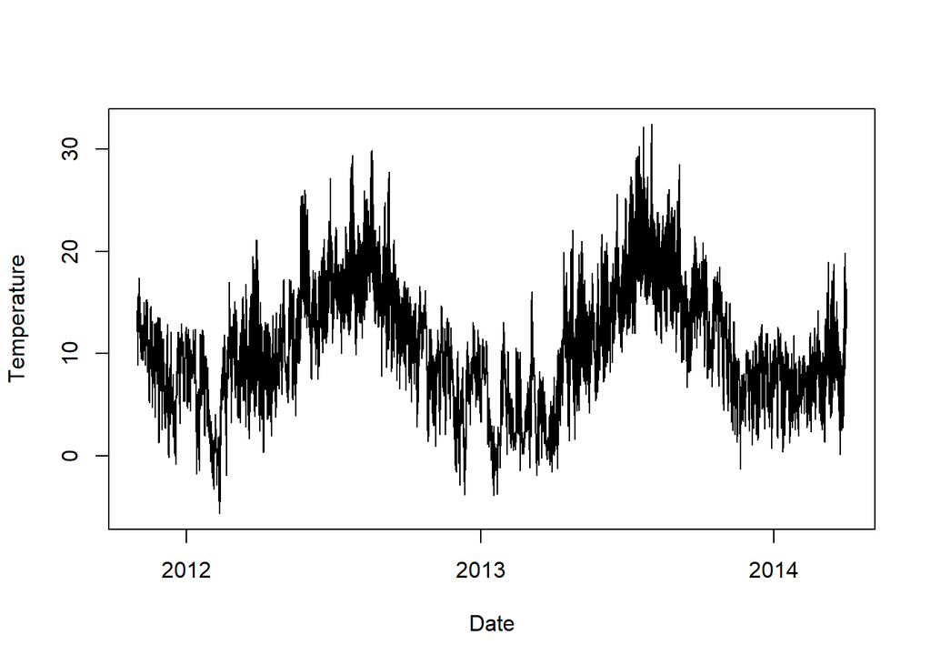

```r
plot(weather_hourly$time, weather_hourly$temperature, ylab="Temperature", xlab="Date", type="l")
```

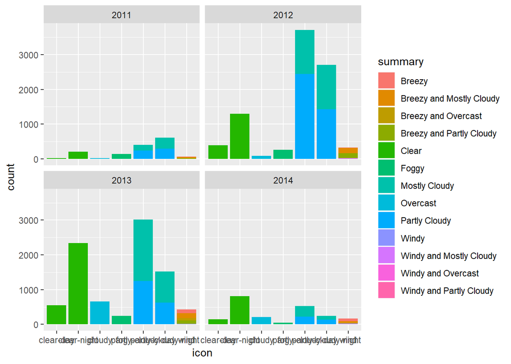

```r
ggplot(weather_hourly,aes(x=icon,fill=summary))+geom_bar()+facet_wrap(~year)
```

# Tariffs

```r
#Carreguem arxiu de dades
tariffs <-read.csv(file="dades/9Tariffs.csv", header=TRUE, sep=";" ,stringsAsFactors = FALSE)
```

```r
#Resum dades

#Dimensi?
dim(tariffs)
```

```
## [1] 17520     2
```

```r
# Resum
summary(tariffs)
```

```
##  TariffDateTime        Tariff
##  Length:17520       Length:17520
##  Class :character   Class :character
##  Mode  :character   Mode  :character
```

```r
# Tipus de dades
str(tariffs)
```

```
## 'data.frame':    17520 obs. of  2 variables:
##  $ TariffDateTime: chr  "2013-01-01 00:00:00" "2013-01-01 00:30:00" "2013-01-01 01:00:00" "2013-01-01 01:30:00" ...
##  $ Tariff        : chr  "Normal" "Normal" "Normal" "Normal" ...
```

Convertim a factor la variable Tariff i a timestamp la variable TariffDateTime

```r
tariffs$Tariff<-as.factor(tariffs$Tariff)
tariffs$TariffDateTime<-as.timeDate(tariffs$TariffDateTime)

str(tariffs)
```

```
## 'data.frame':    17520 obs. of  2 variables:
##  $ TariffDateTime:Formal class 'timeDate' [package "timeDate"] with 3 slots
##   .. ..@ Data     : POSIXct, format: "2013-01-01 00:00:00" ...
##   .. ..@ format   : chr "%Y-%m-%d %H:%M:%S"
##   .. ..@ FinCenter: chr "GMT"
##  $ Tariff        : Factor w/ 3 levels "High","Low","Normal": 3 3 3 3 3 3 3 3 3 3 ...
```

```r
#Mirem si cont? valors buits
colSums(is.na(tariffs))
```

```
## TariffDateTime         Tariff
##              0              0
```

# hhblock_dataset

2hhblock_dataset(tots els blocs) id, dia, hh_1 (consum primera mitja hora), hh2 (consum segona mitja hora)

```r
#Creem una llista amb els noms dels arxius que volem carregar que es troben a la carpeta indicada

library(timereg)
library(mets)
library(data.table)
library(timeDate)

files_hhblock<-list.files(path="dades/2hhblock_dataset")
#print(files_hhblock)

#Anir? a buscar a la carpeta Smart meters/R i per tant cal que tinguem les dades que volem carregar all?.
#Creem dataframe amb les dades de tots els blocs,
hhblock_dataset <- do.call(rbind, lapply(files_hhblock, function(x) as.data.frame(fread(x,header = TRUE))))
head(hhblock_dataset)
```

```
##       LCLid        day  hh_0  hh_1  hh_2  hh_3  hh_4  hh_5  hh_6  hh_7
## 1 MAC000002 2012-10-13 0.263 0.269 0.275 0.256 0.211 0.136 0.161 0.119
## 2 MAC000002 2012-10-14 0.262 0.166 0.226 0.088 0.126 0.082 0.123 0.083
## 3 MAC000002 2012-10-15 0.192 0.097 0.141 0.083 0.132 0.070 0.130 0.074
## 4 MAC000002 2012-10-16 0.237 0.237 0.193 0.118 0.098 0.107 0.094 0.109
## 5 MAC000002 2012-10-17 0.157 0.211 0.155 0.169 0.101 0.117 0.084 0.118
## 6 MAC000002 2012-10-18 0.288 0.259 0.291 0.238 0.170 0.116 0.165 0.112
##    hh_8  hh_9 hh_10 hh_11 hh_12 hh_13 hh_14 hh_15 hh_16 hh_17 hh_18 hh_19
## 1 0.167 0.109 0.168 0.107 0.166 0.117 0.157 0.126 0.146 0.106 0.135 0.191
## 2 0.120 0.079 0.121 0.075 0.124 0.073 0.125 0.070 0.130 0.108 0.196 0.346
## 3 0.124 0.078 0.118 0.082 0.112 0.087 0.106 0.140 0.120 1.075 0.146 0.123
## 4 0.091 0.105 0.091 0.104 0.092 0.103 0.093 0.101 0.144 0.100 0.408 0.102
## 5 0.080 0.119 0.075 0.123 0.071 0.126 0.067 0.124 0.118 0.132 0.358 0.628
## 6 0.166 0.109 0.166 0.106 0.165 0.102 0.164 0.103 0.173 0.145 0.366 0.187
##   hh_20 hh_21 hh_22 hh_23 hh_24 hh_25 hh_26 hh_27 hh_28 hh_29 hh_30 hh_31
```

[output cut: 20 more lines]

```r
#Resum dades

#Dimensi?
dim(hhblock_dataset)
```

```
## [1] 3469352      50
```

```r
# Resum
summary(hhblock_dataset)
```

```
##     LCLid               day                 hh_0             hh_1
##  Length:3469352     Length:3469352     Min.   :0.0000   Min.   :0.0000
##  Class :character   Class :character   1st Qu.:0.0520   1st Qu.:0.0480
##  Mode  :character   Mode  :character   Median :0.0980   Median :0.0880
##                                        Mean   :0.1793   Mean   :0.1693
##                                        3rd Qu.:0.1910   3rd Qu.:0.1680
##                                        Max.   :7.2720   Max.   :8.7170
##
##       hh_2            hh_3             hh_4             hh_5
##  Min.   :0.000   Min.   :0.0000   Min.   :0.0000   Min.   :0.0000
##  1st Qu.:0.046   1st Qu.:0.0440   1st Qu.:0.0420   1st Qu.:0.0420
##  Median :0.081   Median :0.0770   Median :0.0740   Median :0.0720
##  Mean   :0.152   Mean   :0.1381   Mean   :0.1279   Mean   :0.1217
##  3rd Qu.:0.150   3rd Qu.:0.1380   3rd Qu.:0.1300   3rd Qu.:0.1250
##  Max.   :8.025   Max.   :8.7500   Max.   :8.4140   Max.   :8.5910
##
##       hh_6             hh_7             hh_8             hh_9
##  Min.   :0.0000   Min.   :0.0000   Min.   :0.0000   Min.   :0.0000
##  1st Qu.:0.0410   1st Qu.:0.0410   1st Qu.:0.0400   1st Qu.:0.0410
##  Median :0.0710   Median :0.0700   Median :0.0700   Median :0.0710
##  Mean   :0.1171   Mean   :0.1143   Mean   :0.1133   Mean   :0.1158
##  3rd Qu.:0.1220   3rd Qu.:0.1200   3rd Qu.:0.1190   3rd Qu.:0.1220
##  Max.   :7.3570   Max.   :7.6760   Max.   :7.5810   Max.   :7.5680
##
##      hh_10           hh_11            hh_12            hh_13
##  Min.   :0.000   Min.   :0.0000   Min.   :0.0000   Min.   :0.0000
##  1st Qu.:0.041   1st Qu.:0.0430   1st Qu.:0.0460   1st Qu.:0.0500
##  Median :0.072   Median :0.0770   Median :0.0840   Median :0.0950
##  Mean   :0.120   Mean   :0.1315   Mean   :0.1467   Mean   :0.1678
##  3rd Qu.:0.127   3rd Qu.:0.1390   3rd Qu.:0.1570   3rd Qu.:0.1830
##  Max.   :7.273   Max.   :7.6080   Max.   :8.8920   Max.   :8.8120
##
##      hh_14            hh_15            hh_16            hh_17
##  Min.   :0.0000   Min.   :0.0000   Min.   :0.0000   Min.   :0.0000
##  1st Qu.:0.0550   1st Qu.:0.0590   1st Qu.:0.0610   1st Qu.:0.0620
##  Median :0.1060   Median :0.1150   Median :0.1210   Median :0.1240
##  Mean   :0.1848   Mean   :0.2006   Mean   :0.2107   Mean   :0.2163
##  3rd Qu.:0.2070   3rd Qu.:0.2280   3rd Qu.:0.2400   3rd Qu.:0.2460
##  Max.   :9.1660   Max.   :8.7820   Max.   :9.7100   Max.   :9.6500
##
```

[output cut: 49 more lines]

```
##  Min.   :0.0000   Min.   :0.0000   Min.   :0.0000   Min.   :0.0000
##  1st Qu.:0.1080   1st Qu.:0.1030   1st Qu.:0.0920   1st Qu.:0.0790
##  Median :0.2030   Median :0.1950   Median :0.1780   Median :0.1580
##  Mean   :0.3001   Mean   :0.2877   Mean   :0.2663   Mean   :0.2422
##  3rd Qu.:0.3630   3rd Qu.:0.3490   3rd Qu.:0.3230   3rd Qu.:0.2940
##  Max.   :8.5390   Max.   :9.2570   Max.   :7.8190   Max.   :8.0510
##
##      hh_46            hh_47
##  Min.   :0.0000   Min.   :0.0000
##  1st Qu.:0.0670   1st Qu.:0.0580
##  Median :0.1340   Median :0.1130
##  Mean   :0.2144   Mean   :0.1872
##  3rd Qu.:0.2580   3rd Qu.:0.2210
##  Max.   :7.7690   Max.   :8.4110
##
```

```r
# Tipus de dades
str(hhblock_dataset)
```

```
## 'data.frame':    3469352 obs. of  50 variables:
##  $ LCLid: chr  "MAC000002" "MAC000002" "MAC000002" "MAC000002" ...
##  $ day  : chr  "2012-10-13" "2012-10-14" "2012-10-15" "2012-10-16" ...
##  $ hh_0 : num  0.263 0.262 0.192 0.237 0.157 0.288 0.165 0.2 0.39 0.431 ...
##  $ hh_1 : num  0.269 0.166 0.097 0.237 0.211 0.259 0.154 0.229 0.348 0.401 ...
##  $ hh_2 : num  0.275 0.226 0.141 0.193 0.155 0.291 0.173 0.192 0.372 0.294 ...
##  $ hh_3 : num  0.256 0.088 0.083 0.118 0.169 0.238 0.114 0.217 0.341 0.359 ...
##  $ hh_4 : num  0.211 0.126 0.132 0.098 0.101 0.17 0.128 0.18 0.37 0.305 ...
##  $ hh_5 : num  0.136 0.082 0.07 0.107 0.117 0.116 0.082 0.139 0.285 0.353 ...
##  $ hh_6 : num  0.161 0.123 0.13 0.094 0.084 0.165 0.133 0.097 0.272 0.323 ...
##  $ hh_7 : num  0.119 0.083 0.074 0.109 0.118 0.112 0.074 0.12 0.268 0.336 ...
##  $ hh_8 : num  0.167 0.12 0.124 0.091 0.08 0.166 0.133 0.097 0.251 0.447 ...
##  $ hh_9 : num  0.109 0.079 0.078 0.105 0.119 0.109 0.072 0.118 0.287 0.411 ...
##  $ hh_10: num  0.168 0.121 0.118 0.091 0.075 0.166 0.131 0.095 0.232 0.451 ...
##  $ hh_11: num  0.107 0.075 0.082 0.104 0.123 0.106 0.079 0.119 0.286 0.404 ...
```

[output cut: 36 more lines]

Copiem el dataset per si de cas

```r
#hhblock_dataset_copia<- hhblock_dataset
```

```r
#hhblock_dataset<- hhblock_dataset_copia
```

En principi, aquest dataset només l’hem utilitzat per comprovar els valors buits del dataset daily_dataset_csv. Tot i així també tractem les dades per si l’haguéssim de necessitar.

```r
#Mirem si cont? valors buits
colSums(is.na(hhblock_dataset))
```

```
## LCLid   day  hh_0  hh_1  hh_2  hh_3  hh_4  hh_5  hh_6  hh_7  hh_8  hh_9
##     0     0     0     0     0     0     0     0     0     0     0     0
## hh_10 hh_11 hh_12 hh_13 hh_14 hh_15 hh_16 hh_17 hh_18 hh_19 hh_20 hh_21
##     0     0     0     0     0     0     0     0     0     2     0     0
## hh_22 hh_23 hh_24 hh_25 hh_26 hh_27 hh_28 hh_29 hh_30 hh_31 hh_32 hh_33
##     0     0     0    21     2     0     0     0  5460     0     0     0
## hh_34 hh_35 hh_36 hh_37 hh_38 hh_39 hh_40 hh_41 hh_42 hh_43 hh_44 hh_45
##     0     0     1     0     0     0     0     0     0     0     0     0
## hh_46 hh_47
##     0     0
```

```r
colSums(hhblock_dataset=="")
```

```
## LCLid   day  hh_0  hh_1  hh_2  hh_3  hh_4  hh_5  hh_6  hh_7  hh_8  hh_9
##     0     0     0     0     0     0     0     0     0     0     0     0
## hh_10 hh_11 hh_12 hh_13 hh_14 hh_15 hh_16 hh_17 hh_18 hh_19 hh_20 hh_21
##     0     0     0     0     0     0     0     0     0    NA     0     0
## hh_22 hh_23 hh_24 hh_25 hh_26 hh_27 hh_28 hh_29 hh_30 hh_31 hh_32 hh_33
##     0     0     0    NA    NA     0     0     0    NA     0     0     0
## hh_34 hh_35 hh_36 hh_37 hh_38 hh_39 hh_40 hh_41 hh_42 hh_43 hh_44 hh_45
##     0     0    NA     0     0     0     0     0     0     0     0     0
## hh_46 hh_47
##     0     0
```

PEr a tractar els valors buits, primer afegirem la variable “suma total d’energia”.

```r
#Afegim variable total (suma de totes les mitjes hores)
hhblock_dataset$total<-rowSums(hhblock_dataset[,3:50], na.rm=TRUE)
```

Com que els NA de hh_19 nomes contenen aquest valor de NA ( o sigui, no hi ha cap altre Na en la mateixa fila), per obtenir el valor de hh_19 farem la difer?ncia entre el total d’energia del daily_dataset (energy_sum) i del total d’energia de l’hourly (variable total que hem creat) sense el valor NA, i el resultat ser? l’energia consumida a hh_19

Carreguem dataset daily:

```r
#Carreguem arxiu de dades
daily_dataset <-read.csv(file="dades/3daily_dataset_csv.csv", header=TRUE, sep="," ,stringsAsFactors = FALSE)
```

Tractem valors, comencant per hh_19

```r
hhblock_dataset[is.na(hhblock_dataset$hh_19),]
```

```
##             LCLid        day  hh_0  hh_1  hh_2  hh_3  hh_4  hh_5  hh_6
## 736201  MAC001653 2013-10-29 0.241 0.136 0.135 0.108 0.098 0.100 0.132
## 1482545 MAC001477 2013-10-29 0.068 0.048 0.075 0.067 0.097 0.053 0.083
##          hh_7  hh_8  hh_9 hh_10 hh_11 hh_12 hh_13 hh_14 hh_15 hh_16 hh_17
## 736201  0.205 0.198 0.163 0.102 0.127 0.175 0.191 0.217 0.304 0.225 0.411
## 1482545 0.031 0.108 0.026 0.073 0.050 0.078 0.792 1.656 0.444 0.179 0.260
##         hh_18 hh_19 hh_20 hh_21 hh_22 hh_23 hh_24 hh_25 hh_26 hh_27 hh_28
## 736201  0.303    NA 0.229 0.175 0.194 0.241 0.165 0.248 0.231 0.259 0.209
## 1482545 0.244    NA 0.144 0.215 0.227 0.209 0.073 0.240 0.081 0.123 0.100
##         hh_29 hh_30 hh_31 hh_32 hh_33 hh_34 hh_35 hh_36 hh_37 hh_38 hh_39
## 736201  0.188 0.231 0.167 0.220 0.261 0.497 0.770 1.135 1.031 0.786 0.787
## 1482545 0.154 0.305 0.238 0.287 0.176 1.669 0.718 0.320 0.207 1.579 0.998
##         hh_40 hh_41 hh_42 hh_43 hh_44 hh_45 hh_46 hh_47  total
## 736201  0.753 0.692 0.631 0.646 0.660 0.701 0.982 0.334 16.994
## 1482545 0.991 0.175 0.161 0.180 0.089 0.077 0.027 0.108 14.303
```

Tractem hh_19

```r
#Guardem els id dels que tenen NA a hh_19
id<-hhblock_dataset$LCLid[is.na(hhblock_dataset$hh_19)]


#Guardem els dies dels que tenen NA a hh_19
dia<-hhblock_dataset$day[is.na(hhblock_dataset$hh_19)]


for (i in 1:length(id)){
  #Mostrem l?nia que t? NA a hh_19
  hi<- hhblock_dataset[hhblock_dataset$LCLid==id[i] & hhblock_dataset$day==dia[i],]
  hi
  print(hi)
  #Agafem el valor d'energia total (energy_sum) del dataset daily_dataset
  di<-daily_dataset[daily_dataset$LCLid==id[i] & daily_dataset$day==dia[i] ,]

  totalenergy<-di$energy_sum



  #Assignem al valor hh_19 de la llista de ids i dies amb NA el valor de restar a l'energia total de daily el valor de lenergia total del hh ( ja que al fer la suma de l'energia total, no ha tingut amb compte els NA, i la difer?ncia ?s el hh_19)
  hhblock_dataset$hh_19[hhblock_dataset$LCLid==id[i] & hhblock_dataset$day==dia[i]] <- (totalenergy- hi$total)

  #Modifiquem el valor de l'energia total, tornant a sumar tots els hh_x
   hhblock_dataset$total[hhblock_dataset$LCLid==id[i] & hhblock_dataset$day==dia[i]]<- totalenergy

   #Mostrem fila modificada
   hi
}
```

```
##            LCLid        day  hh_0  hh_1  hh_2  hh_3  hh_4 hh_5  hh_6  hh_7
## 736201 MAC001653 2013-10-29 0.241 0.136 0.135 0.108 0.098  0.1 0.132 0.205
##         hh_8  hh_9 hh_10 hh_11 hh_12 hh_13 hh_14 hh_15 hh_16 hh_17 hh_18
## 736201 0.198 0.163 0.102 0.127 0.175 0.191 0.217 0.304 0.225 0.411 0.303
##        hh_19 hh_20 hh_21 hh_22 hh_23 hh_24 hh_25 hh_26 hh_27 hh_28 hh_29
## 736201    NA 0.229 0.175 0.194 0.241 0.165 0.248 0.231 0.259 0.209 0.188
##        hh_30 hh_31 hh_32 hh_33 hh_34 hh_35 hh_36 hh_37 hh_38 hh_39 hh_40
## 736201 0.231 0.167  0.22 0.261 0.497  0.77 1.135 1.031 0.786 0.787 0.753
##        hh_41 hh_42 hh_43 hh_44 hh_45 hh_46 hh_47  total
## 736201 0.692 0.631 0.646  0.66 0.701 0.982 0.334 16.994
##             LCLid        day  hh_0  hh_1  hh_2  hh_3  hh_4  hh_5  hh_6
## 1482545 MAC001477 2013-10-29 0.068 0.048 0.075 0.067 0.097 0.053 0.083
##          hh_7  hh_8  hh_9 hh_10 hh_11 hh_12 hh_13 hh_14 hh_15 hh_16 hh_17
## 1482545 0.031 0.108 0.026 0.073  0.05 0.078 0.792 1.656 0.444 0.179  0.26
##         hh_18 hh_19 hh_20 hh_21 hh_22 hh_23 hh_24 hh_25 hh_26 hh_27 hh_28
## 1482545 0.244    NA 0.144 0.215 0.227 0.209 0.073  0.24 0.081 0.123   0.1
##         hh_29 hh_30 hh_31 hh_32 hh_33 hh_34 hh_35 hh_36 hh_37 hh_38 hh_39
## 1482545 0.154 0.305 0.238 0.287 0.176 1.669 0.718  0.32 0.207 1.579 0.998
##         hh_40 hh_41 hh_42 hh_43 hh_44 hh_45 hh_46 hh_47  total
## 1482545 0.991 0.175 0.161  0.18 0.089 0.077 0.027 0.108 14.303
```

Tractem hh_25

```r
hhblock_dataset[is.na(hhblock_dataset$hh_25),]
```

```
##             LCLid        day  hh_0  hh_1  hh_2  hh_3  hh_4  hh_5  hh_6
## 64      MAC000002 2012-12-19 0.258 0.281 0.330 0.289 0.212 0.227 0.082
## 209271  MAC005564 2012-12-19 0.047 0.041 0.014 0.051 0.039 0.014 0.016
## 726907  MAC005554 2012-12-19 0.170 0.106 0.098 0.063 0.111 0.078 0.079
## 727701  MAC005566 2012-12-19 0.130 0.071 0.135 0.126 0.059 0.138 0.084
## 794276  MAC005555 2012-12-19 0.071 0.093 0.072 0.139 0.104 0.075 0.093
## 1213685 MAC000012 2012-12-19 0.000 0.000 0.015 0.055 0.037 0.000 0.000
## 1404193 MAC000004 2012-12-19 0.000 0.000 0.000 0.000 0.011 0.151 0.000
## 1793726 MAC000005 2012-12-19 0.057 0.028 0.031 0.031 0.031 0.029 0.030
## 1948972 MAC005562 2012-12-19 0.028 0.050 0.047 0.017 0.044 0.055 0.031
## 2221315 MAC000010 2012-12-19 1.045 0.334 0.222 0.181 0.222 0.212 0.151
## 2252412 MAC000007 2012-12-19 0.237 0.212 0.231 0.203 0.099 0.066 0.066
## 2284902 MAC000008 2012-12-19 0.226 0.244 0.210 0.202 0.247 0.194 0.210
## 2635569 MAC000013 2012-12-19 0.081 0.118 0.116 0.084 0.066 0.068 0.132
## 2761808 MAC000014 2012-12-19 0.037 0.020 0.030 0.034 0.016 0.033 0.016
```

[output cut: 95 more lines]

```r
#Guardem els id dels que tenen NA a hh_25
id<-hhblock_dataset$LCLid[is.na(hhblock_dataset$hh_25)]



#Guardem els dies dels que tenen NA a hh_25
dia<-hhblock_dataset$day[is.na(hhblock_dataset$hh_25)]



for (i in 1:length(dia)){
  #Mostrem l?nia que t? NA a hh_25
  hi<- hhblock_dataset[hhblock_dataset$LCLid==id[i] & hhblock_dataset$day==dia[i],]
  hi
  #Agafem el valor d'energia total (energy_sum) del dataset daily_dataset
  di<-daily_dataset[daily_dataset$LCLid==id[i] & daily_dataset$day==dia[i] ,]

  totalenergy<-di$energy_sum


  #Assignem al valor hh_25 de la llista de ids i dies amb NA el valor de restar a l'energia total de daily el valor de lenergia total del hh ( ja que al fer la suma de l'energia total, no ha tingut amb compte els NA, i la difer?ncia ?s el hh_25)
  hhblock_dataset$hh_25[hhblock_dataset$LCLid==id[i] & hhblock_dataset$day==dia[i]] <- (totalenergy- hi$total)

  #Modifiquem el valor de l'energia total, tornant a sumar tots els hh_x
   hhblock_dataset$total[hhblock_dataset$LCLid==id[i] & hhblock_dataset$day==dia[i]]<- totalenergy


}
```

Tractem hh_26

```r
hhblock_dataset[is.na(hhblock_dataset$hh_26),]
```

```
##            LCLid        day  hh_0  hh_1  hh_2  hh_3  hh_4  hh_5  hh_6
## 442108 MAC002328 2013-07-05 0.053 0.045 0.022 0.024 0.006 0.018 0.028
## 453480 MAC004069 2013-07-05 0.058 0.056 0.061 0.053 0.062 0.055 0.058
##         hh_7  hh_8  hh_9 hh_10 hh_11 hh_12 hh_13 hh_14 hh_15 hh_16 hh_17
## 442108 0.009 0.015 0.023 0.009 0.015 0.022 0.004 0.019 0.028 0.000 0.024
## 453480 0.056 0.057 0.057 0.054 0.068 0.103 0.107 0.101 0.110 0.103 0.106
##        hh_18 hh_19 hh_20 hh_21 hh_22 hh_23 hh_24 hh_25 hh_26 hh_27 hh_28
## 442108 0.009 0.015 0.031 0.008 0.033 0.033 0.018 0.028    NA 0.026 0.013
## 453480 0.105 0.094 0.080 0.057 0.055 0.059 0.054 0.054    NA 0.080 0.058
##        hh_29 hh_30 hh_31 hh_32 hh_33 hh_34 hh_35 hh_36 hh_37 hh_38 hh_39
## 442108 0.028 0.023 0.035 0.057 0.032 0.008 0.023 0.023  0.00 0.023 0.023
## 453480 0.057 0.059 0.071 0.109 0.105 0.107 0.108 0.111  0.11 0.108 0.105
##        hh_40 hh_41 hh_42 hh_43 hh_44 hh_45 hh_46 hh_47 total
## 442108 0.014 0.018 0.063 0.074 0.023 0.090 0.042 0.033 1.210
## 453480 0.107 0.110 0.110 0.109 0.105 0.101 0.062 0.057 3.832
```

```r
#Guardem els id dels que tenen NA a hh_26
id<-hhblock_dataset$LCLid[is.na(hhblock_dataset$hh_26)]

#Guardem els dies dels que tenen NA a hh_26
dia<-hhblock_dataset$day[is.na(hhblock_dataset$hh_26)]

for (i in 1:length(id)){
  #Mostrem l?nia que t? NA a hh_26
  hi<- hhblock_dataset[hhblock_dataset$LCLid==id[i] & hhblock_dataset$day==dia[i],]

  #Agafem el valor d'energia total (energy_sum) del dataset daily_dataset
  di<-daily_dataset[daily_dataset$LCLid==id[i] & daily_dataset$day==dia[i] ,]

  totalenergy<-di$energy_sum

  #Assignem al valor hh_26 de la llista de ids i dies amb NA el valor de restar a l'energia total de daily el valor de lenergia total del hh ( ja que al fer la suma de l'energia total, no ha tingut amb compte els NA, i la difer?ncia ?s el hh_26)
  hhblock_dataset$hh_26[hhblock_dataset$LCLid==id[i] & hhblock_dataset$day==dia[i]] <- (totalenergy- hi$total)

  #Modifiquem el valor de l'energia total, tornant a sumar tots els hh_x
   hhblock_dataset$total[hhblock_dataset$LCLid==id[i] & hhblock_dataset$day==dia[i]]<- totalenergy


}
```

Tractem els hh_30

```r
hhblock_dataset[is.na(hhblock_dataset$hh_30),]
```

```
##             LCLid        day  hh_0  hh_1  hh_2  hh_3  hh_4  hh_5  hh_6
## 878     MAC000246 2012-12-18 1.097 1.018 0.847 0.509 0.821 0.446 0.064
## 1577    MAC000450 2012-12-18 1.333 1.106 1.118 1.189 0.896 0.865 1.027
## 1942    MAC001074 2012-12-18 0.345 0.268 0.202 0.260 0.189 0.161 0.341
## 2036    MAC003223 2012-12-18 0.350 0.468 0.305 0.190 0.117 0.073 0.060
## 2561    MAC003239 2012-12-18 0.062 0.048 0.046 0.066 0.030 0.038 0.077
## 3080    MAC003252 2012-12-18 0.168 0.065 0.058 0.147 0.122 0.120 0.062
## 3594    MAC003281 2012-12-18 0.503 0.465 0.477 0.529 0.452 0.489 0.481
## 4113    MAC003305 2012-12-18 0.538 0.764 0.830 0.163 0.144 0.092 0.092
## 4554    MAC003348 2012-12-18 0.207 0.056 0.054 0.076 0.041 0.079 0.067
## 5068    MAC003388 2012-12-18 0.505 0.521 0.417 0.255 0.162 0.128 0.140
## 5584    MAC003394 2012-12-18 0.161 0.146 0.170 0.154 0.153 0.167 0.147
## 6093    MAC003400 2012-12-18 0.298 0.096 0.091 0.056 0.051 0.051 0.060
## 6600    MAC003422 2012-12-18 0.892 0.878 0.824 0.828 0.895 0.901 0.849
## 7093    MAC003423 2012-12-18 0.425 0.427 0.403 0.331 0.397 0.287 0.358
```

[output cut: 9791 more lines]

```r
#Guardem els id dels que tenen NA a hh_30
id<-hhblock_dataset$LCLid[is.na(hhblock_dataset$hh_30)]

#Guardem els dies dels que tenen NA a hh_30
dia<-hhblock_dataset$day[is.na(hhblock_dataset$hh_30)]


for (i in 1:length(id)){
  #Mostrem l?nia que t? NA a hh_30
  hi<- hhblock_dataset[hhblock_dataset$LCLid==id[i] & hhblock_dataset$day==dia[i],]

  #Agafem el valor d'energia total (energy_sum) del dataset daily_dataset
  di<-daily_dataset[daily_dataset$LCLid==id[i] & daily_dataset$day==dia[i] ,]

  totalenergy<-di$energy_sum

  #Assignem al valor hh_30 de la llista de ids i dies amb NA el valor de restar a l'energia total de daily el valor de lenergia total del hh ( ja que al fer la suma de l'energia total, no ha tingut amb compte els NA, i la difer?ncia ?s el hh_30)
  hhblock_dataset$hh_30[hhblock_dataset$LCLid==id[i] & hhblock_dataset$day==dia[i]] <- (totalenergy- hi$total)

  #Modifiquem el valor de l'energia total, tornant a sumar tots els hh_x
   hhblock_dataset$total[hhblock_dataset$LCLid==id[i] & hhblock_dataset$day==dia[i]]<- totalenergy

}
```

Tractem els hh_36

```r
hhblock_dataset[is.na(hhblock_dataset$hh_36),]
```

```
##            LCLid        day  hh_0  hh_1  hh_2 hh_3  hh_4  hh_5  hh_6  hh_7
## 460177 MAC005567 2012-12-20 0.185 0.109 0.083 0.06 0.046 0.047 0.051 0.035
##         hh_8  hh_9 hh_10 hh_11 hh_12 hh_13 hh_14 hh_15 hh_16 hh_17 hh_18
## 460177 0.062 0.047 0.035 0.056 0.038 0.044 0.061 0.035 0.034 0.064 0.044
##        hh_19 hh_20 hh_21 hh_22 hh_23 hh_24 hh_25 hh_26 hh_27 hh_28 hh_29
## 460177  0.24 0.065 0.078 0.069 0.043 0.051 0.079  0.04 0.282 0.137 0.061
##        hh_30 hh_31 hh_32 hh_33 hh_34 hh_35 hh_36 hh_37 hh_38 hh_39 hh_40
## 460177 0.067 0.143 0.118 0.113 0.159 0.045    NA 0.066 0.046 0.059 0.053
##        hh_41 hh_42 hh_43 hh_44 hh_45 hh_46 hh_47 total
## 460177 0.055 0.068 0.082 0.146  0.11 0.074 0.055  3.74
```

```r
#Guardem els id dels que tenen NA a hh_36
id<-hhblock_dataset$LCLid[is.na(hhblock_dataset$hh_36)]



#Guardem els dies dels que tenen NA a hh_36
dia<-hhblock_dataset$day[is.na(hhblock_dataset$hh_36)]


for (i in 1:length(id)){
  #Mostrem l?nia que t? NA a hh_36
  hi<- hhblock_dataset[hhblock_dataset$LCLid==id[i] & hhblock_dataset$day==dia[i],]

  #Agafem el valor d'energia total (energy_sum) del dataset daily_dataset
  di<-daily_dataset[daily_dataset$LCLid==id[i] & daily_dataset$day==dia[i] ,]

  totalenergy<-di$energy_sum

  #Mostrem energia total
  totalenergy

  #Assignem al valor hh_36 de la llista de ids i dies amb NA el valor de restar a l'energia total de daily el valor de lenergia total del hh ( ja que al fer la suma de l'energia total, no ha tingut amb compte els NA, i la difer?ncia ?s el hh_36)
  hhblock_dataset$hh_36[hhblock_dataset$LCLid==id[i] & hhblock_dataset$day==dia[i]] <- (totalenergy- hi$total)

  #Modifiquem el valor de l'energia total, tornant a sumar tots els hh_x
   hhblock_dataset$total[hhblock_dataset$LCLid==id[i] & hhblock_dataset$day==dia[i]]<- totalenergy

}
```

Copiem el dataset per no haver de tornar a carregar i treure NA si ens equivoquem

```r
hhblock_dataset_copia_ple <- hhblock_dataset
```

```r
#Comrprovem que no hi ha NA
colSums(is.na(hhblock_dataset))
```

```
## LCLid   day  hh_0  hh_1  hh_2  hh_3  hh_4  hh_5  hh_6  hh_7  hh_8  hh_9
##     0     0     0     0     0     0     0     0     0     0     0     0
## hh_10 hh_11 hh_12 hh_13 hh_14 hh_15 hh_16 hh_17 hh_18 hh_19 hh_20 hh_21
##     0     0     0     0     0     0     0     0     0     0     0     0
## hh_22 hh_23 hh_24 hh_25 hh_26 hh_27 hh_28 hh_29 hh_30 hh_31 hh_32 hh_33
##     0     0     0     0     0     0     0     0     0     0     0     0
## hh_34 hh_35 hh_36 hh_37 hh_38 hh_39 hh_40 hh_41 hh_42 hh_43 hh_44 hh_45
##     0     0     0     0     0     0     0     0     0     0     0     0
## hh_46 hh_47 total
##     0     0     0
```

Fem transformacions a les variables

```r
#Passem de chr a factor la data
hhblock_dataset$day<-as.Date(hhblock_dataset$day)
```

```r
#Ordenem les dades de weather_daily per data
hhblock_dataset<-hhblock_dataset[order(hhblock_dataset$day),]
```

# Halfhourly_dataset

Podem carregar el fiter però no tenim suficient RAM per tractar les dades, de manera que ho farem en un altre arxiu individual. Ens surt l’error Error: cannot allocate vector of size 3.8 Gb i comprovem i és cert que només tenim disponibles 3.1GB de RAM de 16GB.

# Exportem dades

```r
write.csv(weather_hourly,file="C:/Users/Laura/Desktop/Smart meters London/workspace R/Dades netes/weather_hourly.csv")
write.csv(tariffs,file="C:/Users/Laura/Desktop/Smart meters London/workspace R/Dades netes/tariffs.csv")
write.csv(hhblock_dataset,file="C:/Users/Laura/Desktop/Smart meters London/workspace R/Dades netes/hhblock_dataset.csv")
```